# 重賞レース予測レポート【レース終了】

作成日時: 2026/01/04 18:30:26

☞ [マニュアル(pdf)](https://ryutoro-galois.github.io/keiba-predictor/manual/manual.pdf)

☞ 過去6年の同一レース結果: [2025年](https://ryutoro-galois.github.io/keiba-predictor/report/PredResult_2025y_raceDate_20250105_20250105.html), [2024年](https://ryutoro-galois.github.io/keiba-predictor/report/PredResult_2024y_raceDate_20240106_20240108.html), [2023年](https://ryutoro-galois.github.io/keiba-predictor/report/PredResult_2023y_raceDate_20230105_20230105.html), [2022年](https://ryutoro-galois.github.io/keiba-predictor/report/PredResult_2022y_raceDate_20220105_20220105.html), [2021年](https://ryutoro-galois.github.io/keiba-predictor/report/PredResult_2021y_raceDate_20210105_20210105.html), [2020年](https://ryutoro-galois.github.io/keiba-predictor/report/PredResult_2020y_raceDate_20200105_20200105.html)

☞ 過去4週間の別レース結果: [1週前(12/27-28)](https://ryutoro-galois.github.io/keiba-predictor/report/PredResult_2025y_raceDate_20251227_20251228.html), [2週前(12/20-21)](https://ryutoro-galois.github.io/keiba-predictor/report/PredResult_2025y_raceDate_20251220_20251221.html), [3週前(12/13-14)](https://ryutoro-galois.github.io/keiba-predictor/report/PredResult_2025y_raceDate_20251213_20251214.html), [4週前(12/6-7)](https://ryutoro-galois.github.io/keiba-predictor/report/PredResult_2025y_raceDate_20251206_20251207.html)

☞ netkeiba: [中山金杯(GⅢ)](https://race.netkeiba.com/race/result.html?race_id=202606010111&rf=race_submenu), [京都金杯(GⅢ)](https://race.netkeiba.com/race/result.html?race_id=202608010111&rf=race_submenu)

☞ レース結果(csv): [1/4](https://ryutoro-galois.github.io/keiba-predictor/csv/race_result_20260104_20260104.csv)

## 【レース結果(1)】人気と着順の関係

### 【中山金杯(2026/01/04(日))】

【中山金杯(GⅢ)】  
2026/01/04(日), 06_中山, 芝右2000m

[interactive chart not shown]

### 【京都金杯(2026/01/04(日))】

【京都金杯(GⅢ)】  
2026/01/04(日), 08_京都, 芝右外1600m

[interactive chart not shown]

## 【レース結果(2)】コーナー通過順位

### 【中山金杯(2026/01/04(日))】

【中山金杯(GⅢ)】  
2026/01/04(日), 06_中山, 芝右2000m

[interactive chart not shown]

### 【京都金杯(2026/01/04(日))】

【京都金杯(GⅢ)】  
2026/01/04(日), 08_京都, 芝右外1600m

[interactive chart not shown]

## 0. 推し馬予測 (AI予測)

### 【中山金杯(GⅢ) 2026/01/04(日)】

- 本命(◎): 1-3着内確率(勝負強さ)が1位の馬
- 対抗(◯): 1-3着内確率が2-N位(20%程度以上)の中で予測タイムが最も速い馬
- 3番手(▲): 1-3着内確率が2-N位(20%程度以上)のでダークホース確率が最も高い馬
- 穴: ダークホース確率が上位1-M位(40%程度以上)の中で1-3着内確率が最も高い馬

| 推し馬 | 枠番 | 馬番 | 人気 | オッズ | 馬名 | 騎手 | 調教師 | 予測タイム(sec) | 1_順位 | 1-3着内確率(%) | 2_順位 | ﾀﾞｰｸﾎｰｽ確率(%) | 3_順位 |
| --- | --- | --- | --- | --- | --- | --- | --- | --- | --- | --- | --- | --- | --- |
| 本命(◎) | 3 | 3 | 2 | 4.9 | カネラフィーナ | 石川裕紀人 | 手塚貴久 | 126.2 | 6 | 31.2 | 1 | 0.6 | 13 |
| 対抗(◯) | 2 | 2 | 1 | 3.2 | アンゴラブラック | 戸崎圭太 | 尾関知人 | 117.8 | 1 | 27.7 | 2 | 0.6 | 14 |
| 3番手(▲) | 1 | 1 | 3 | 7.6 | ケイアイセナ | 吉田隼人 | 平田修 | 124.7 | 5 | 26.1 | 3 | 1.6 | 12 |
| 穴 | 7 | 12 | 9 | 18.3 | マイネルモーント | 丹内祐次 | 高木登 | 123.9 | 4 | 10.8 | 7 | 65.2 | 1 |

### 【京都金杯(GⅢ) 2026/01/04(日)】

- 本命(◎): 1-3着内確率(勝負強さ)が1位の馬
- 対抗(◯): 1-3着内確率が2-N位(20%程度以上)の中で予測タイムが最も速い馬
- 3番手(▲): 1-3着内確率が2-N位(20%程度以上)のでダークホース確率が最も高い馬
- 穴: ダークホース確率が上位1-M位(40%程度以上)の中で1-3着内確率が最も高い馬

| 推し馬 | 枠番 | 馬番 | 人気 | オッズ | 馬名 | 騎手 | 調教師 | 予測タイム(sec) | 1_順位 | 1-3着内確率(%) | 2_順位 | ﾀﾞｰｸﾎｰｽ確率(%) | 3_順位 |
| --- | --- | --- | --- | --- | --- | --- | --- | --- | --- | --- | --- | --- | --- |
| 本命(◎) | 7 | 13 | 5 | 10.3 | ガイアメンテ | 北村友一 | 須貝尚介 | 95.1 | 8 | 39.6 | 1 | 1.2 | 12 |
| 対抗(◯) | 1 | 1 | 1 | 2.8 | ランスオブカオス | 吉村誠之助 | 奥村豊 | 92.5 | 2 | 21.9 | 4 | 0.4 | 18 |
| 3番手(▲) | 2 | 3 | 2 | 6.0 | キープカルム | 坂井瑠星 | 中竹和也 | 94.7 | 7 | 31.8 | 2 | 1.4 | 10 |
| 穴 | 5 | 10 | 18 | 88.9 | ショウナンアデイブ | 池添謙一 | 高野友和 | 103.3 | 17 | 5.0 | 12 | 40.1 | 1 |

## 1. 予測チャート (タイム/勝負強さ)

### 【中山金杯(GⅢ)】

2026/01/04(日), 06_中山, 芝右2000m

[interactive chart not shown]

### 【京都金杯(GⅢ)】

2026/01/04(日), 08_京都, 芝右外1600m

[interactive chart not shown]

## 2. オッズモニタリング (毎時)

### 【中山金杯】

[interactive chart not shown]

### 【京都金杯】

[interactive chart not shown]

## 3. 出馬表

### 【中山金杯 2026/01/04(日) 】

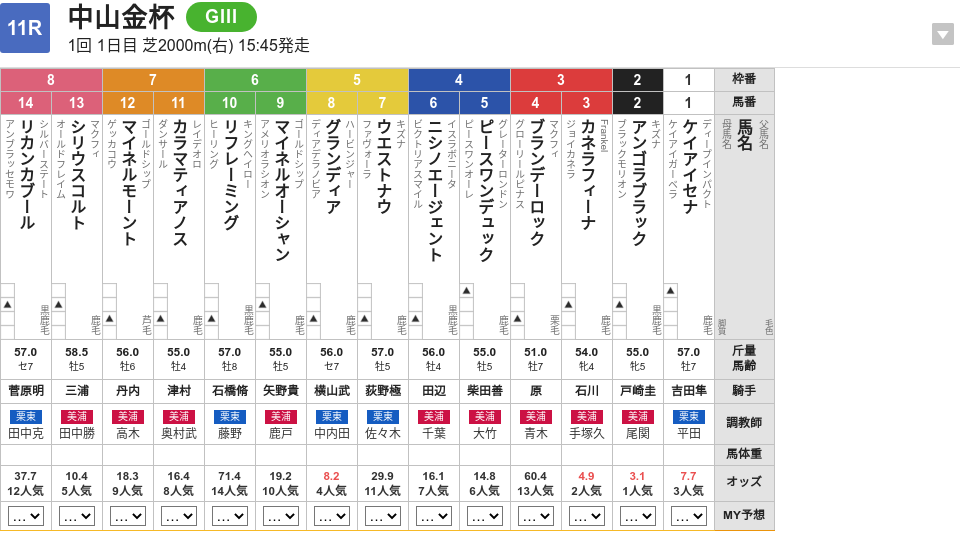

### 【京都金杯 2026/01/04(日) 】

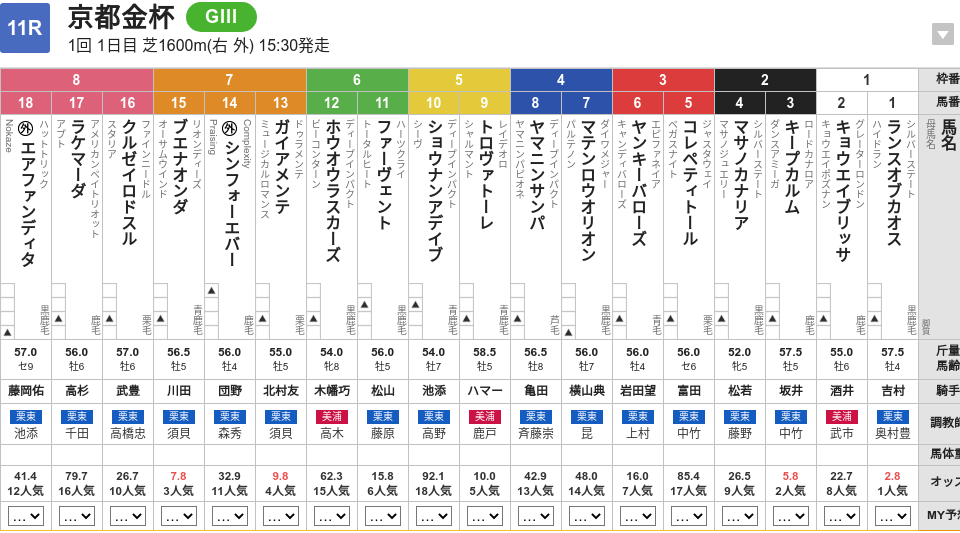

## 4. 単勝予測結果

### 【中山金杯(GⅢ) 2026/01/04(日)】

| 枠番 | 馬番 | 人気 | オッズ | 馬名 | 騎手 | 調教師 | 予測タイム(sec) | 1_順位 | 1-3着内確率(%) | 2_順位 | ﾀﾞｰｸﾎｰｽ確率(%) | 3_順位 |
| --- | --- | --- | --- | --- | --- | --- | --- | --- | --- | --- | --- | --- |
| 1 | 1 | 3 | 7.6 | ケイアイセナ | 吉田隼人 | 平田修 | 124.7 | 5 | 26.1 | 3 | 1.6 | 12 |
| 2 | 2 | 1 | 3.2 | アンゴラブラック | 戸崎圭太 | 尾関知人 | 117.8 | 1 | 27.7 | 2 | 0.6 | 14 |
| 3 | 3 | 2 | 4.9 | カネラフィーナ | 石川裕紀人 | 手塚貴久 | 126.2 | 6 | 31.2 | 1 | 0.6 | 13 |
| 3 | 4 | 13 | 59.0 | ブランデーロック | 原優介 | 青木孝文 | 132.5 | 13 | 2.1 | 13 | 15.1 | 7 |
| 4 | 5 | 6 | 14.9 | ピースワンデュック | 柴田善臣 | 大竹正博 | 121.1 | 3 | 14.1 | 4 | 2.9 | 8 |
| 4 | 6 | 7 | 16.2 | ニシノエージェント | 田辺裕信 | 千葉直人 | 127.1 | 8 | 8.6 | 9 | 1.7 | 11 |
| 5 | 7 | 11 | 29.8 | ウエストナウ | 荻野極 | 佐々木晶三 | 127.4 | 10 | 6.7 | 10 | 46.8 | 3 |
| 5 | 8 | 4 | 8.2 | グランディア | 横山武史 | 中内田充正 | 119.0 | 2 | 10.9 | 6 | 1.7 | 9 |
| 6 | 9 | 10 | 18.9 | マイネルオーシャン | 矢野貴之 | 鹿戸雄一 | 133.2 | 14 | 2.1 | 12 | 16.9 | 5 |
| 6 | 10 | 14 | 70.8 | リフレーミング | 石橋脩 | 藤野健太 | 129.7 | 11 | 2.2 | 11 | 16.0 | 6 |

[output cut: 4 more lines]

### 【京都金杯(GⅢ) 2026/01/04(日)】

| 枠番 | 馬番 | 人気 | オッズ | 馬名 | 騎手 | 調教師 | 予測タイム(sec) | 1_順位 | 1-3着内確率(%) | 2_順位 | ﾀﾞｰｸﾎｰｽ確率(%) | 3_順位 |
| --- | --- | --- | --- | --- | --- | --- | --- | --- | --- | --- | --- | --- |
| 1 | 1 | 1 | 2.8 | ランスオブカオス | 吉村誠之助 | 奥村豊 | 92.5 | 2 | 21.9 | 4 | 0.4 | 18 |
| 1 | 2 | 8 | 22.0 | キョウエイブリッサ | 酒井学 | 武市康男 | 100.5 | 14 | 2.9 | 13 | 1.0 | 17 |
| 2 | 3 | 2 | 6.0 | キープカルム | 坂井瑠星 | 中竹和也 | 94.7 | 7 | 31.8 | 2 | 1.4 | 10 |
| 2 | 4 | 9 | 25.9 | マサノカナリア | 松若風馬 | 藤野健太 | 93.0 | 4 | 13.6 | 7 | 1.4 | 11 |
| 3 | 5 | 17 | 83.7 | コレペティトール | 富田暁 | 中竹和也 | 100.2 | 10 | 2.3 | 17 | 34.1 | 2 |
| 3 | 6 | 7 | 16.0 | ヤンキーバローズ | 岩田望来 | 上村洋行 | 92.5 | 2 | 13.5 | 8 | 1.2 | 13 |
| 4 | 7 | 14 | 46.9 | マテンロウオリオン | 横山典弘 | 昆貢 | 100.5 | 13 | 2.3 | 18 | 9.4 | 9 |
| 4 | 8 | 13 | 42.2 | ヤマニンサンパ | 亀田温心 | 斉藤崇史 | 100.3 | 12 | 2.6 | 15 | 13.4 | 7 |
| 5 | 9 | 4 | 9.7 | トロヴァトーレ | Ｔ．ハマーハンセン | 鹿戸雄一 | 93.2 | 5 | 23.2 | 3 | 1.1 | 15 |
| 5 | 10 | 18 | 88.9 | ショウナンアデイブ | 池添謙一 | 高野友和 | 103.3 | 17 | 5.0 | 12 | 40.1 | 1 |

[output cut: 8 more lines]

## 5. 人気と着順の乖離率推移

### 【中山金杯_1996y_2019y】

[interactive chart not shown]

### 【京都金杯_1996y_2019y】

[interactive chart not shown]

### 【中山金杯_1996y_2019y】

| No | 開催年 | 不整合率(%) | 頭数 | 人気別着順(1-3位) | 人気別着順(全体) |
| --- | --- | --- | --- | --- | --- |
| 24 | 2019 | 56.9 | 16頭 | 3-7-9 | 3\|7\|9\|8\|2\|16\|4\|5\|11\|12\|14\|1\|6\|13\|10\|15 |
| 23 | 2018 | 14.4 | 17頭 | 1-2-10 | 1\|2\|10\|4\|3\|9\|6\|14\|15\|5\|12\|7\|13\|8\|11\|17\|16 |
| 22 | 2017 | 32.5 | 13頭 | 1-6-4 | 1\|6\|4\|9\|11\|12\|5\|8\|2\|3\|10\|7\|13 |
| 21 | 2016 | 41.5 | 13頭 | 3-5-1 | 3\|5\|1\|6\|7\|2\|9\|4\|11\|10\|12\|8\|13 |
| 20 | 2015 | 49.0 | 17頭 | 4-1-5 | 4\|1\|5\|15\|11\|8\|16\|9\|7\|13\|6\|14\|17\|3\|2\|12\|10 |
| 19 | 2014 | 41.1 | 16頭 | 5-8-1 | 5\|8\|1\|9\|3\|16\|7\|13\|4\|11\|2\|6\|10\|12\|14\|15 |
| 18 | 2013 | 29.0 | 16頭 | 2-4-1 | 2\|4\|1\|7\|3\|10\|11\|5\|9\|6\|8\|12\|14\|16\|13\|15 |
| 17 | 2012 | 48.2 | 16頭 | 2-4-5 | 2\|4\|5\|6\|3\|14\|8\|10\|7\|9\|13\|12\|11\|15\|16\|1 |
| 16 | 2011 | 29.8 | 16頭 | 1-11-5 | 1\|11\|5\|4\|6\|14\|15\|2\|12\|7\|8\|3\|13\|9\|10\|16 |
| 15 | 2010 | 32.6 | 16頭 | 1-5-15 | 1\|5\|15\|7\|6\|4\|2\|8\|11\|12\|3\|10\|13\|14\|9\|16 |

[output cut: 14 more lines]

### 【京都金杯_1996y_2019y】

| No | 開催年 | 不整合率(%) | 頭数 | 人気別着順(1-3位) | 人気別着順(全体) |
| --- | --- | --- | --- | --- | --- |
| 24 | 2019 | 33.3 | 17頭 | 1-5-11 | 1\|5\|11\|7\|6\|4\|2\|3\|16\|14\|12\|9\|8\|17\|13\|10\|15 |
| 23 | 2018 | 52.2 | 13頭 | 4-3-1 | 4\|3\|1\|6\|8\|11\|7\|2\|13\|9\|12\|10\|5 |
| 22 | 2017 | 24.2 | 18頭 | 1-6-5 | 1\|6\|5\|2\|8\|9\|10\|7\|3\|12\|14\|16\|4\|11\|13\|17\|18\|15 |
| 21 | 2016 | 57.8 | 17頭 | 3-13-7 | 3\|13\|7\|5\|15\|6\|4\|9\|11\|1\|12\|2\|16\|10\|8\|14\|17 |
| 20 | 2015 | 45.9 | 18頭 | 5-4-7 | 5\|4\|7\|2\|1\|15\|13\|3\|10\|12\|6\|18\|11\|16\|8\|17\|9\|14 |
| 19 | 2014 | 49.7 | 16頭 | 6-1-5 | 6\|1\|5\|11\|8\|13\|15\|4\|14\|9\|3\|7\|12\|16\|2\|10 |
| 18 | 2013 | 17.8 | 16頭 | 1-6-7 | 1\|6\|7\|2\|9\|3\|4\|14\|11\|13\|10\|12\|5\|16\|8\|15 |
| 17 | 2012 | 48.0 | 16頭 | 3-2-10 | 3\|2\|10\|4\|1\|6\|8\|16\|9\|7\|11\|12\|14\|13\|15\|5 |
| 16 | 2011 | 47.3 | 16頭 | 7-3-2 | 7\|3\|2\|1\|8\|4\|11\|13\|6\|10\|5\|9\|12\|15\|16\|14 |
| 15 | 2010 | 35.9 | 15頭 | 5-1-13 | 5\|1\|13\|9\|2\|11\|12\|10\|15\|7\|6\|8\|4\|3\|14 |

[output cut: 14 more lines]

## 6. 1-3番人気馬の着順分類予測

### 【中山金杯】

| 分類 | 凡例 | 発生確率(%) | 当該レース | 当該レースランク | 直近1年間 |
| --- | --- | --- | --- | --- | --- |
| 1: 1番人気のみ (1_pop1) | 1 \| * \| * | 16.3 | 0.61 | 0.44 | 0.33 |
| 3: 3番人気のみ (3_pop3) | 3 \| * \| * | 15.7 | 0.59 | 0.86 | 0.31 |
| 4: 1,2番人気のみ (4_pop12) | 1 \| 2 \| * | 15.3 | 0.76 | 1.53 | 0.00 |
| 8: 1,2,3番人気すべて着外 (8_darkhorse) | * \| * \| * | 15.1 | 1.51 | 1.82 | 0.00 |
| 5: 1,3番人気のみ (5_pop13) | 1 \| 3 \| * | 12.6 | 1.88 | 0.95 | 0.00 |
| 6: 2,3番人気のみ (6_pop23) | 2 \| 3 \| * | 9.2 | 1.37 | 1.11 | 0.00 |
| 2: 2番人気のみ (2_pop2) | 2 \| * \| * | 8.7 | 2.64 | 2.64 | 0.00 |
| 7: 1,2,3番人気すべて着内 (7_pop123) | 1 \| 2 \| 3 | 7.1 | 0.00 | 4.18 | 0.00 |

### 【京都金杯】

| 分類 | 凡例 | 発生確率(%) | 当該レース | 当該レースランク | 直近1年間 |
| --- | --- | --- | --- | --- | --- |
| 1: 1番人気のみ (1_pop1) | 1 \| * \| * | 19.2 | 0.41 | 0.52 | 0.38 |
| 4: 1,2番人気のみ (4_pop12) | 1 \| 2 \| * | 15.8 | 0.00 | 1.58 | 0.00 |
| 8: 1,2,3番人気すべて着外 (8_darkhorse) | * \| * \| * | 15.6 | 2.33 | 1.88 | 0.00 |
| 5: 1,3番人気のみ (5_pop13) | 1 \| 3 \| * | 13.1 | 0.66 | 0.98 | 0.00 |
| 3: 3番人気のみ (3_pop3) | 3 \| * \| * | 10.7 | 1.07 | 0.58 | 0.21 |
| 6: 2,3番人気のみ (6_pop23) | 2 \| 3 \| * | 9.5 | 0.95 | 1.14 | 0.00 |
| 2: 2番人気のみ (2_pop2) | 2 \| * \| * | 9.0 | 2.73 | 2.73 | 0.00 |
| 7: 1,2,3番人気すべて着内 (7_pop123) | 1 \| 2 \| 3 | 7.3 | 2.21 | 4.29 | 0.00 |

## 7. 3連複予測結果

### 【中山金杯(GⅢ) 2026/01/04(日)】

| 分類 | 馬番 | 枠番 | 人気 | 平均予測タイム(sec) | 1-3着内確率(%) | ﾀﾞｰｸﾎｰｽ確率(%) | 馬名 | 騎手 | 調教師 |
| --- | --- | --- | --- | --- | --- | --- | --- | --- | --- |
| 7: 1,2,3番人気すべて着内 (7_pop123) | 2-3-1 | 2-3-1 | 1-2-3 | 122.90 | 2.25 | 0.00 | アンゴラブラック \| カネラフィーナ \| ケイアイセナ | 戸崎圭太 \| 石川裕紀人 \| 吉田隼人 | 尾関知人 \| 手塚貴久 \| 平田修 |
| 4: 1,2番人気のみ (4_pop12) | 2-3-5 | 2-3-4 | 1-2-6 | 121.70 | 1.22 | 0.00 | アンゴラブラック \| カネラフィーナ \| ピースワンデュック | 戸崎圭太 \| 石川裕紀人 \| 柴田善臣 | 尾関知人 \| 手塚貴久 \| 大竹正博 |
| 6: 2,3番人気のみ (6_pop23) | 3-1-5 | 3-1-4 | 2-3-6 | 124.00 | 1.15 | 0.00 | カネラフィーナ \| ケイアイセナ \| ピースワンデュック | 石川裕紀人 \| 吉田隼人 \| 柴田善臣 | 手塚貴久 \| 平田修 \| 大竹正博 |
| 5: 1,3番人気のみ (5_pop13) | 2-1-5 | 2-1-4 | 1-3-6 | 121.20 | 1.02 | 0.00 | アンゴラブラック \| ケイアイセナ \| ピースワンデュック | 戸崎圭太 \| 吉田隼人 \| 柴田善臣 | 尾関知人 \| 平田修 \| 大竹正博 |
| 4: 1,2番人気のみ (4_pop12) | 2-3-13 | 2-3-8 | 1-2-5 | 123.73 | 0.96 | 0.00 | アンゴラブラック \| カネラフィーナ \| シリウスコルト | 戸崎圭太 \| 石川裕紀人 \| 三浦皇成 | 尾関知人 \| 手塚貴久 \| 田中勝春 |
| 4: 1,2番人気のみ (4_pop12) | 2-3-8 | 2-3-5 | 1-2-4 | 121.00 | 0.94 | 0.00 | アンゴラブラック \| カネラフィーナ \| グランディア | 戸崎圭太 \| 石川裕紀人 \| 横山武史 | 尾関知人 \| 手塚貴久 \| 中内田充正 |
| 4: 1,2番人気のみ (4_pop12) | 2-3-12 | 2-3-7 | 1-2-9 | 122.63 | 0.93 | 0.00 | アンゴラブラック \| カネラフィーナ \| マイネルモーント | 戸崎圭太 \| 石川裕紀人 \| 丹内祐次 | 尾関知人 \| 手塚貴久 \| 高木登 |
| 6: 2,3番人気のみ (6_pop23) | 3-1-13 | 3-1-8 | 2-3-5 | 126.03 | 0.91 | 0.00 | カネラフィーナ \| ケイアイセナ \| シリウスコルト | 石川裕紀人 \| 吉田隼人 \| 三浦皇成 | 手塚貴久 \| 平田修 \| 田中勝春 |
| 6: 2,3番人気のみ (6_pop23) | 3-1-8 | 3-1-5 | 2-3-4 | 123.30 | 0.89 | 0.00 | カネラフィーナ \| ケイアイセナ \| グランディア | 石川裕紀人 \| 吉田隼人 \| 横山武史 | 手塚貴久 \| 平田修 \| 中内田充正 |
| 6: 2,3番人気のみ (6_pop23) | 3-1-12 | 3-1-7 | 2-3-9 | 124.93 | 0.88 | 0.01 | カネラフィーナ \| ケイアイセナ \| マイネルモーント | 石川裕紀人 \| 吉田隼人 \| 丹内祐次 | 手塚貴久 \| 平田修 \| 高木登 |

[output cut: 354 more lines]

### 【京都金杯(GⅢ) 2026/01/04(日)】

| 分類 | 馬番 | 枠番 | 人気 | 平均予測タイム(sec) | 1-3着内確率(%) | ﾀﾞｰｸﾎｰｽ確率(%) | 馬名 | 騎手 | 調教師 |
| --- | --- | --- | --- | --- | --- | --- | --- | --- | --- |
| 2: 2番人気のみ (2_pop2) | 3-9-13 | 2-5-7 | 2-4-5 | 94.33 | 2.92 | 0.00 | キープカルム \| トロヴァトーレ \| ガイアメンテ | 坂井瑠星 \| Ｔ．ハマーハンセン \| 北村友一 | 中竹和也 \| 鹿戸雄一 \| 須貝尚介 |
| 4: 1,2番人気のみ (4_pop12) | 1-3-13 | 1-2-7 | 1-2-5 | 94.10 | 2.75 | 0.00 | ランスオブカオス \| キープカルム \| ガイアメンテ | 吉村誠之助 \| 坂井瑠星 \| 北村友一 | 奥村豊 \| 中竹和也 \| 須貝尚介 |
| 1: 1番人気のみ (1_pop1) | 1-9-13 | 1-5-7 | 1-4-5 | 93.60 | 2.01 | 0.00 | ランスオブカオス \| トロヴァトーレ \| ガイアメンテ | 吉村誠之助 \| Ｔ．ハマーハンセン \| 北村友一 | 奥村豊 \| 鹿戸雄一 \| 須貝尚介 |
| 6: 2,3番人気のみ (6_pop23) | 3-15-13 | 2-7-7 | 2-3-5 | 95.87 | 1.91 | 0.00 | キープカルム \| ブエナオンダ \| ガイアメンテ | 坂井瑠星 \| 川田将雅 \| 北村友一 | 中竹和也 \| 須貝尚介 \| 須貝尚介 |
| 2: 2番人気のみ (2_pop2) | 3-13-11 | 2-7-6 | 2-5-6 | 94.10 | 1.74 | 0.00 | キープカルム \| ガイアメンテ \| ファーヴェント | 坂井瑠星 \| 北村友一 \| 松山弘平 | 中竹和也 \| 須貝尚介 \| 藤原英昭 |
| 2: 2番人気のみ (2_pop2) | 3-13-4 | 2-7-2 | 2-5-9 | 94.27 | 1.71 | 0.00 | キープカルム \| ガイアメンテ \| マサノカナリア | 坂井瑠星 \| 北村友一 \| 松若風馬 | 中竹和也 \| 須貝尚介 \| 藤野健太 |
| 2: 2番人気のみ (2_pop2) | 3-13-6 | 2-7-3 | 2-5-7 | 94.10 | 1.70 | 0.00 | キープカルム \| ガイアメンテ \| ヤンキーバローズ | 坂井瑠星 \| 北村友一 \| 岩田望来 | 中竹和也 \| 須貝尚介 \| 上村洋行 |
| 4: 1,2番人気のみ (4_pop12) | 1-3-9 | 1-2-5 | 1-2-4 | 93.47 | 1.61 | 0.00 | ランスオブカオス \| キープカルム \| トロヴァトーレ | 吉村誠之助 \| 坂井瑠星 \| Ｔ．ハマーハンセン | 奥村豊 \| 中竹和也 \| 鹿戸雄一 |
| 3: 3番人気のみ (3_pop3) | 15-9-13 | 7-5-7 | 3-4-5 | 95.37 | 1.40 | 0.00 | ブエナオンダ \| トロヴァトーレ \| ガイアメンテ | 川田将雅 \| Ｔ．ハマーハンセン \| 北村友一 | 須貝尚介 \| 鹿戸雄一 \| 須貝尚介 |
| 5: 1,3番人気のみ (5_pop13) | 1-15-13 | 1-7-7 | 1-3-5 | 95.13 | 1.32 | 0.00 | ランスオブカオス \| ブエナオンダ \| ガイアメンテ | 吉村誠之助 \| 川田将雅 \| 北村友一 | 奥村豊 \| 須貝尚介 \| 須貝尚介 |

[output cut: 806 more lines]

## 8. 直近の全レース情報

| No | 日付 | 競馬場 | R | 発走 | レース名 | 距離 | 頭数 | URL(netkeiba) |
| --- | --- | --- | --- | --- | --- | --- | --- | --- |
| 1 | 2026/01/04(日) | 06_中山 | 1R |  | 3歳未勝利 | 1200 | 16頭 | https://race.netkeiba.com/race/shutuba.html?race_id=202606010101&amp;rf=race_list |
| 2 | 2026/01/04(日) | 06_中山 | 2R |  | 3歳未勝利 | 1800 | 17頭 | https://race.netkeiba.com/race/shutuba.html?race_id=202606010102&amp;rf=race_list |
| 3 | 2026/01/04(日) | 06_中山 | 3R |  | 3歳新馬 | 1200 | 24頭 | https://race.netkeiba.com/race/shutuba.html?race_id=202606010103&amp;rf=race_list |
| 4 | 2026/01/04(日) | 06_中山 | 4R |  | 3歳未勝利 | 1800 | 5頭 | https://race.netkeiba.com/race/shutuba.html?race_id=202606010104&amp;rf=race_list |
| 5 | 2026/01/04(日) | 06_中山 | 5R |  | 3歳未勝利 | 1600 | 24頭 | https://race.netkeiba.com/race/shutuba.html?race_id=202606010105&amp;rf=race_list |
| 6 | 2026/01/04(日) | 06_中山 | 6R |  | 3歳新馬 | 2000 | 17頭 | https://race.netkeiba.com/race/shutuba.html?race_id=202606010106&amp;rf=race_list |
| 7 | 2026/01/04(日) | 06_中山 | 7R |  | 4歳以上1勝クラス | 1800 | 17頭 | https://race.netkeiba.com/race/shutuba.html?race_id=202606010107&amp;rf=race_list |
| 8 | 2026/01/04(日) | 06_中山 | 8R |  | 4歳以上1勝クラス | 1200 | 18頭 | https://race.netkeiba.com/race/shutuba.html?race_id=202606010108&amp;rf=race_list |
| 9 | 2026/01/04(日) | 06_中山 | 9R | 14:30 | 招福S | 1800 | 11頭 | https://race.netkeiba.com/race/shutuba.html?race_id=202606010109&amp;rf=race_list |
| 10 | 2026/01/04(日) | 06_中山 | 10R | 15:05 | ジュニアC | 1600 | 9頭 | https://race.netkeiba.com/race/shutuba.html?race_id=202606010110&amp;rf=race_list |

[output cut: 38 more lines]